# Parameter Estimation - Wild Fish Catch

Joe Walderman

3/5/2021

```r
knitr::opts_chunk$set(echo = TRUE, message = FALSE, warning = FALSE)
library(tidyverse)
library(here)
library(janitor)
library(boot) # for bootstrapping
library(gt) # table formatting
library(nlstools) # nonlinear least squares fit
library(broom)
```

## Overview

In this analysis we will use nonlinear least squares to look at wild fish catch data from 1950-2012 generated by the Earth Policy Institute.

## Exploration of the Data: Time Series and Parameter Estimation

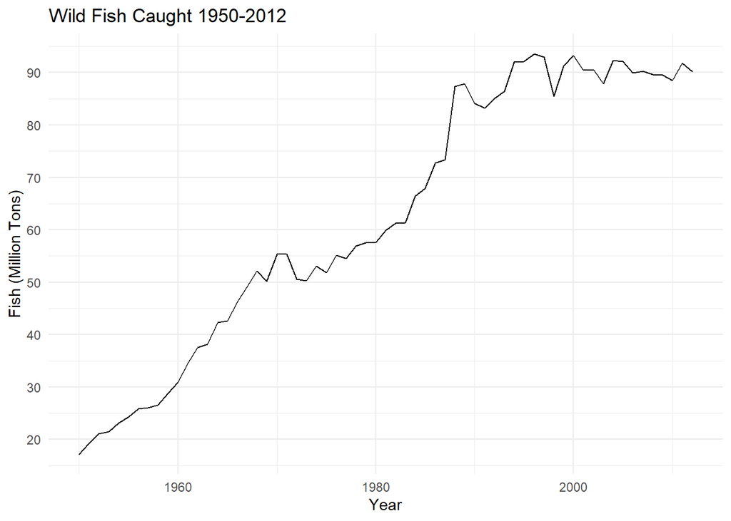

```r
# Reading in and wrangling the data
fish <- read_csv(here("data", "fish_catch.csv"), skip = 2) %>%
  drop_na() %>%
  clean_names() %>%
  mutate(year = as.numeric(year)) %>%
  mutate(wild_catch = as.numeric(wild_catch)) %>%
  mutate(year_number = 0:62)

# Fish catch time series plot
ggplot(data = fish, aes(x = year, y = wild_catch)) +
  geom_line() +
  scale_y_continuous(breaks = c(10,20,30,40,50,60,70,80,90,100)) +
  labs(x = "Year",
       y = "Fish (Million Tons)",
       title = "Wild Fish Caught 1950-2012") +
  theme_minimal()
```

```r
fish_exp <- fish %>%
  filter(year < 1990) %>%
  mutate(ln_wild = log(wild_catch))

# Linear model to get k estimate
lm_k <- lm(ln_wild ~ year_number, data = fish_exp)
lm_tidy <- tidy(lm_k)
```

This exploratory graph shows a generally increasing trend of wild fish catch over time. The growth pattern seems to be one of logistic growth, exhibited by initial exponential growth eventually leveling off at a carrying capacity. This growth can be described mathematically as:

$P(t) = \frac{K}{1+Ae^{-kt}}$

*K Estimate*: Around 1990 fish catch seems to level off at around 90-95 million tons per year. Thus the estimate for carrying capacity *K* is **95** million tons.

*A Estimate*: The population at 1950, time zero in this case, is ~18 milion tons. Thus *A* ~ $\frac{95-18}{18}$ ~ **4.3**

*k Estimate*: k is estimated by looking at log of wild fish before 1990 to get the growth rate. It is estimated to be *k* = ~**0.04**.

## Nonlinear Least Squares for Parameter Estimation

```r
# NLS Model
fish_nls <- nls(wild_catch ~ K/(1 + A*exp(-r*year_number)),
                data = fish,
                start = list(K = 95,
                             A = 4.3,
                             r = 0.04),
                trace = TRUE)

# Model summary
#summary(fish_nls)

# Tidy output
fish_output <- tidy(fish_nls)
```

```r
# Results Table
fish_output %>%
  mutate(p.value = case_when(
    p.value < 0.0001 ~ "<0.0001"
  )) %>%
  gt() %>%
  tab_header(
    title = "Nonlinear Least Squares Output"
  ) %>%
  fmt_number(columns = vars(estimate, std.error, statistic),
             decimals = 2
  ) %>%
  cols_label(
    term = "Term",
    estimate = "Estimate",
    std.error = "Standard Error",
    statistic = "Statistic",
    p.value = "P-Value"
  )
```

Nonlinear Least Squares Output

| Term | Estimate | Standard Error | Statistic | P-Value |
| --- | --- | --- | --- | --- |
| K | 100.28 | 2.73 | 36.68 | <0.0001 |
| A | 4.32 | 0.29 | 14.73 | <0.0001 |
| r | 0.07 | 0.00 | 15.04 | <0.0001 |

## Prediction Visualization

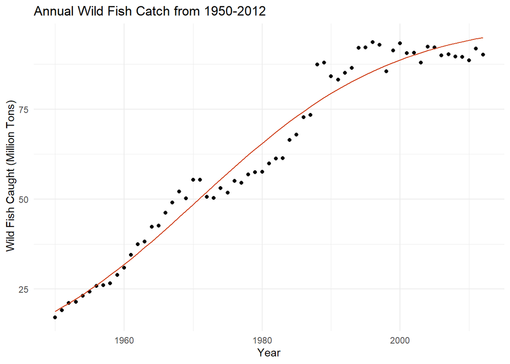

```r
# Predictions
fish_predict <- predict(fish_nls)

# Combine the data frames into a single plot
fish_complete <- data.frame(fish, fish_predict)

# Plotting
ggplot(data = fish_complete, aes(x = year, y = wild_catch)) +
  geom_point() +
  geom_line(aes(y = fish_predict), color = "orangered3") +
  theme_minimal() +
  labs(x = "Year",
       y = " Wild Fish Caught (Million Tons)",
       title = "Annual Wild Fish Catch from 1950-2012")
```

## Citation:

[Global wild fish catch and aquaculture production, compiled by Earth Policy Institute with 1950-2010 from U.N. Food and Agriculture Organization (FAO), Global Capture Production and Global Aquaculture Production, electronic databases, at www.fao.org/fishery/topic/16140/en.](https://drive.google.com/file/d/1sKjDqxbpWD7vd7Kt4tBNpl6pHEf_LnIe/view)